# R markdown: reproducible report in data science

Allen Cosme

2026-02-02 13:22:02.707359

# 1 R markdown

R markdown is a format for writing reproducible, dynamic reports with R. Use it to embed R code and results into slide shows, PDF files, HTML documents, word files and more

# 2 Structure

1. YAML header
2. text area
3. Code chunk

# 3 Workflow

1. Open - open a file that uses the . RMD extension.
2. Write - Write content with the easy to use R markedown syntax
3. Embed - Embed R code that creates output to include in the report
4. Render - Replace R code with its output and transform the report into a slideshow, pdf, html or MS word file

# 4 Text Area Formating tools

plain text

end a line with two spaces to start a new paragraph

*italics* and *italics*.

**Bold** and **bold**.

superscript<sup>2</sup>.

Strikethrough.

Hyperlink [CCIDM](https://www.cpp.edu/cba/customer-insights-lab/index.shtml)

# 5 header 1

## 5.1 header 2

### 5.1.1 header 3

#### 5.1.1.1 header 4

##### 5.1.1.1.1 haeder 6

Endash – emdash — inline equation $A= \pi*r^2$ slide break:

> block quote
1. ordered list 1
2. ordered list 2
- sub-item 1
- sub-item 2

| Table header | second header |
| --- | --- |
| Table cell. | cell 2 |
| cell 3. | cell 4 |

# 6 YAML Header

> A YAML header is a set of key value pairs at the start of your file. Begin and end the header with a line of 3 dashes (—). (From the rmd cheatsheet https://www.rstudio.com/wp-content/uploads/2015/02/rmarkdown-cheatsheet.pdf)
- **date**: ‘2026-02-02 13:22:02’
  - this allows to print the current time each time you knit the file
    - can be customized in various ways
    - date+time: 2026-02-02 13:22:02.717433
    - Day, month, date, year (e.g., Sunday, January 15, 2026): ‘Monday, February, 20, 02/02/26’
    - M/D/Y (e.g., 01/25/2026): ‘02/02/26’
- **toc**: yes - I turned the table of contents on. This will have hyperlinks in HTML and allow renders to navigate desired sections faster
- **toc_depth**: 4 - I want to see 4 levels of headings _ **toc_float** : true - adding this move toc from the front end of the document to the left side floating when you scroll down - by default, the floating toc are collapsed, not showing all headings. We can turn it off using the following code `toc_float: collapsed: false`
- **highlight**: espresso
- **theme**: journal
- **number_sections**: yes
  - turned on automatic section numbering

# 7 Embed Codes

## 7.1 code chunk

### 7.1.1 Sample

- ctrl + alt + I

```r
#use ctrl+enter to run code
#install.packages("tidyverse")
library(tidyverse)
#install.packages("palmerpenguins")
library(palmerpenguins)
penguins
```

```
## # A tibble: 344 × 8
##    species island    bill_length_mm bill_depth_mm flipper_length_mm body_mass_g
##    <fct>   <fct>              <dbl>         <dbl>             <int>       <int>
##  1 Adelie  Torgersen           39.1          18.7               181        3750
##  2 Adelie  Torgersen           39.5          17.4               186        3800
##  3 Adelie  Torgersen           40.3          18                 195        3250
##  4 Adelie  Torgersen           NA            NA                  NA          NA
##  5 Adelie  Torgersen           36.7          19.3               193        3450
##  6 Adelie  Torgersen           39.3          20.6               190        3650
##  7 Adelie  Torgersen           38.9          17.8               181        3625
##  8 Adelie  Torgersen           39.2          19.6               195        4675
##  9 Adelie  Torgersen           34.1          18.1               193        3475
## 10 Adelie  Torgersen           42            20.2               190        4250
## # ℹ 334 more rows
## # ℹ 2 more variables: sex <fct>, year <int>
```

```r
dim(penguins)
```

```
## [1] 344   8
```

```r
install.packages("skimr", repos = "https://cloud.r-project.org")
library(skimr)
skimr::skim(penguins)
```

Data summary

| Name | penguins |
| --- | --- |
| Number of rows | 344 |
| Number of columns | 8 |
| _______________________ |  |
| Column type frequency: |  |
| factor | 3 |
| numeric | 5 |
| ________________________ |  |
| Group variables | None |

**Variable type: factor**

| skim_variable | n_missing | complete_rate | ordered | n_unique | top_counts |
| --- | --- | --- | --- | --- | --- |
| species | 0 | 1.00 | FALSE | 3 | Ade: 152, Gen: 124, Chi: 68 |
| island | 0 | 1.00 | FALSE | 3 | Bis: 168, Dre: 124, Tor: 52 |
| sex | 11 | 0.97 | FALSE | 2 | mal: 168, fem: 165 |

**Variable type: numeric**

| skim_variable | n_missing | complete_rate | mean | sd | p0 | p25 | p50 | p75 | p100 | hist |
| --- | --- | --- | --- | --- | --- | --- | --- | --- | --- | --- |
| bill_length_mm | 2 | 0.99 | 43.92 | 5.46 | 32.1 | 39.23 | 44.45 | 48.5 | 59.6 | ▃▇▇▆▁ |
| bill_depth_mm | 2 | 0.99 | 17.15 | 1.97 | 13.1 | 15.60 | 17.30 | 18.7 | 21.5 | ▅▅▇▇▂ |
| flipper_length_mm | 2 | 0.99 | 200.92 | 14.06 | 172.0 | 190.00 | 197.00 | 213.0 | 231.0 | ▂▇▃▅▂ |
| body_mass_g | 2 | 0.99 | 4201.75 | 801.95 | 2700.0 | 3550.00 | 4050.00 | 4750.0 | 6300.0 | ▃▇▆▃▂ |
| year | 0 | 1.00 | 2008.03 | 0.82 | 2007.0 | 2007.00 | 2008.00 | 2009.0 | 2009.0 | ▇▁▇▁▇ |

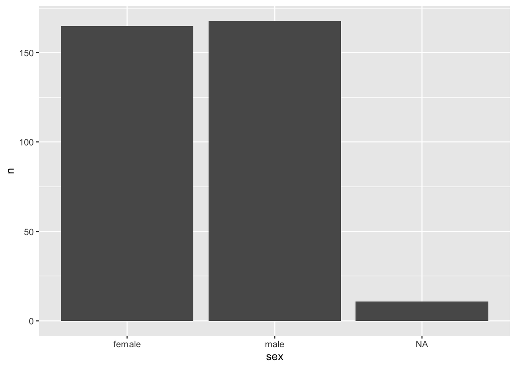

```r
#sex distribution
penguins %>%
  count(sex) %>%
  ggplot(aes(sex, n)) +
  geom_col()
```

```r
# of male penquins
  sum(penguins$sex =="male", na.rm = TRUE)
```

```
## [1] 168
```

```r
#total observations
nrow(penguins)
```

```
## [1] 344
```

```r
# percentage of males
m_per <- round((sum(penguins$sex == "male", na.rm = TRUE) / nrow(penguins)) * 100, 1)
#percentage of females
f_per <- round((sum(penguins$sex == "female", na.rm = TRUE) / nrow(penguins)) * 100, 1)
```